# BI-2020 Statistics Project №3

# 1 Сделать описание датасета

```r
prot_expr <-
  read_xls('~/Git_Repositories/BI_2019_Stats/Stat_project_3/Data_Cortex_Nuclear.xls')
```

Определим количество мышей с учётом знания того, что было взято 15 образцов:

```r
length(prot_expr$MouseID)/15
```

```
## [1] 72
```

Взглянем на структуру данных и выделим группы. Кроме того, взглянем на баланс данны в группах:

```r
prot_expr_chars <- prot_expr %>% select_if(is.character)
apply(prot_expr_chars[,-1], MARGIN = 2, function(x) table(x))
```

```
## $Genotype
## x
## Control  Ts65Dn
##     570     510
##
## $Treatment
## x
## Memantine    Saline
##       570       510
##
## $Behavior
## x
## C/S S/C
## 525 555
##
## $class
## x
## c-CS-m c-CS-s c-SC-m c-SC-s t-CS-m t-CS-s t-SC-m t-SC-s
##    150    135    150    135    135    105    135    135
```

В целом данные достаточно сбалансировано раскинуты по группам.

Определим количество полных наблюдений:

```r
nrow(prot_expr) - length(which(rowSums(is.na(prot_expr)) > 0))
```

```
## [1] 552
```

Внесём числовые значения в отдельный датасет, уберём пропуски, так как усреднение по такому большому количеству данных может негативно сказаться на результатах анализа:

```r
prot_expr_omited <- na.omit(prot_expr)
prot_expr_chars <- prot_expr_omited[,-1] %>% select_if(is.character)
prot_expr_num <- prot_expr_omited %>% select_if(is.numeric)
```

# 2 Есть ли различия в уровне продукции BDNF_N в зависимости от класса в эксперименте

Убедимся, что данная переменная распределена нормально:

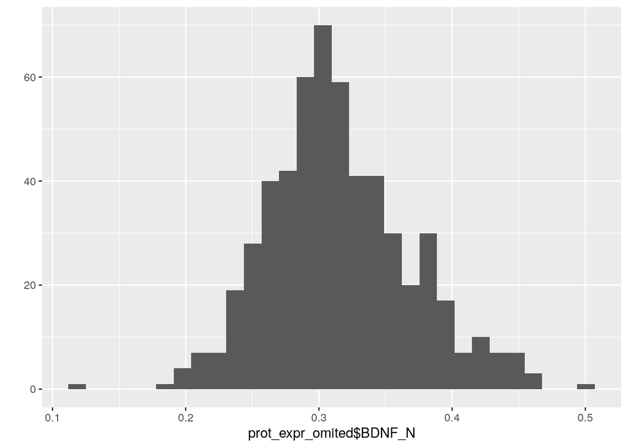

```r
qplot(prot_expr_omited$BDNF_N, geom = 'histogram')
```

Так как данные распределены нормально, смело используем ANOVA для проверки на различия:

```r
fit <- aov(BDNF_N ~ class, prot_expr_omited)
summary(fit)
```

```
##              Df Sum Sq  Mean Sq F value   Pr(>F)
## class         7 0.1346 0.019233   7.304 2.18e-08 ***
## Residuals   544 1.4324 0.002633
## ---
## Signif. codes:  0 '***' 0.001 '**' 0.01 '*' 0.05 '.' 0.1 ' ' 1
```

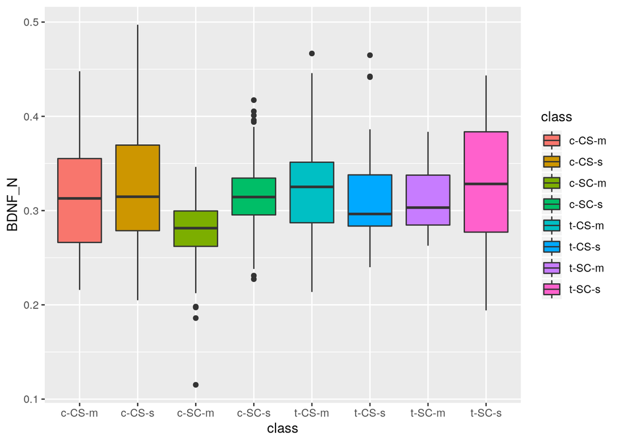

```r
ggplot(prot_expr_omited, aes(x = class, y = BDNF_N, fill = class)) +
    geom_boxplot()
```

Различия действительно есть. Для выявления конкретных различий используем парный Т тест с поправкой Бонферрони:

```r
pairwise.t.test(prot_expr_omited$BDNF_N, prot_expr_omited$class, p.adjust.method = 'bonferroni')
```

```
##
##  Pairwise comparisons using t tests with pooled SD
##
## data:  prot_expr_omited$BDNF_N and prot_expr_omited$class
##
##        c-CS-m  c-CS-s  c-SC-m  c-SC-s t-CS-m t-CS-s t-SC-m
## c-CS-s 1.0000  -       -       -      -      -      -
## c-SC-m 4.5e-05 1.7e-07 -       -      -      -      -
## c-SC-s 1.0000  1.0000  5.4e-05 -      -      -      -
## t-CS-m 1.0000  1.0000  3.9e-07 1.0000 -      -      -
## t-CS-s 1.0000  1.0000  0.0019  1.0000 1.0000 -      -
## t-SC-m 1.0000  1.0000  0.0015  1.0000 1.0000 1.0000 -
## t-SC-s 1.0000  1.0000  9.7e-08 1.0000 1.0000 0.8965 1.0000
##
## P value adjustment method: bonferroni
```

# 3 Попробовать построить линейную модель, способную предсказать уровень продукции белка ERBB4_N на основании данных о других белках в эксперименте

Подберём оптимальную модель с помощью функции step:

```r
model_full <- lm(ERBB4_N ~ ., prot_expr_num)
model_null <- lm(ERBB4_N ~ 1, prot_expr_num)
optimal_model <- step(model_full, scope = list(lower = model_null, upper = model_full))
```

```r
summary(optimal_model)
```

```
##
## Call:
## lm(formula = ERBB4_N ~ BDNF_N + NR1_N + pAKT_N + pBRAF_N + pCREB_N +
##     pERK_N + pJNK_N + pNR1_N + pNR2A_N + pNR2B_N + pPKCAB_N +
##     pRSK_N + BRAF_N + ELK_N + ERK_N + SOD1_N + MTOR_N + pMTOR_N +
##     RAPTOR_N + TIAM1_N + NUMB_N + P70S6_N + pGSK3B_N + pPKCG_N +
##     S6_N + ADARB1_N + RRP1_N + BAX_N + ARC_N + Tau_N + GluR4_N +
##     IL1B_N + P3525_N + pCASP9_N + PSD95_N + pGSK3B_Tyr216_N +
##     SHH_N + BAD_N + SYP_N, data = prot_expr_num)
##
## Residuals:
##       Min        1Q    Median        3Q       Max
## -0.022896 -0.003445 -0.000143  0.003315  0.032643
##
## Coefficients:
##                  Estimate Std. Error t value Pr(>|t|)
## (Intercept)      0.021113   0.006566   3.216 0.001384 **
## BDNF_N           0.037235   0.016172   2.302 0.021715 *
## NR1_N           -0.013454   0.005062  -2.658 0.008113 **
## pAKT_N           0.083801   0.022858   3.666 0.000272 ***
## pBRAF_N         -0.049834   0.026675  -1.868 0.062308 .
## pCREB_N         -0.058424   0.023156  -2.523 0.011935 *
## pERK_N          -0.023565   0.005834  -4.039 6.18e-05 ***
## pJNK_N          -0.067350   0.018529  -3.635 0.000306 ***
## pNR1_N          -0.026835   0.011353  -2.364 0.018464 *
## pNR2A_N          0.012583   0.004594   2.739 0.006378 **
## pNR2B_N          0.019205   0.005045   3.807 0.000158 ***
## pPKCAB_N         0.005386   0.001710   3.150 0.001726 **
## pRSK_N           0.015183   0.009966   1.523 0.128274
## BRAF_N           0.017065   0.009379   1.820 0.069417 .
## ELK_N            0.005793   0.002431   2.383 0.017542 *
## ERK_N            0.005754   0.001628   3.534 0.000447 ***
## SOD1_N          -0.005504   0.002418  -2.276 0.023267 *
## MTOR_N           0.036109   0.011147   3.239 0.001276 **
## pMTOR_N         -0.010894   0.005454  -1.997 0.046304 *
## RAPTOR_N         0.036489   0.018366   1.987 0.047479 *
## TIAM1_N         -0.025117   0.012480  -2.013 0.044689 *
## NUMB_N          -0.058760   0.025995  -2.260 0.024215 *
## P70S6_N         -0.006341   0.003856  -1.645 0.100686
## pGSK3B_N         0.114093   0.030177   3.781 0.000175 ***
## pPKCG_N         -0.006855   0.001490  -4.602 5.29e-06 ***
## S6_N             0.018544   0.004892   3.790 0.000168 ***
## ADARB1_N        -0.002341   0.001400  -1.671 0.095256 .
## RRP1_N          -0.015826   0.009243  -1.712 0.087456 .
## BAX_N           -0.137161   0.026562  -5.164 3.47e-07 ***
## ARC_N            0.203525   0.046051   4.420 1.21e-05 ***
## Tau_N            0.078622   0.009468   8.304 9.04e-16 ***
## GluR4_N         -0.071481   0.023760  -3.008 0.002755 **
## IL1B_N           0.021528   0.008734   2.465 0.014036 *
## P3525_N          0.045699   0.018465   2.475 0.013651 *
## pCASP9_N         0.009798   0.002298   4.265 2.38e-05 ***
## PSD95_N          0.023565   0.002791   8.443 3.19e-16 ***
## pGSK3B_Tyr216_N  0.023629   0.006455   3.660 0.000278 ***
## SHH_N            0.049931   0.016485   3.029 0.002579 **
## BAD_N           -0.051574   0.021484  -2.401 0.016725 *
## SYP_N            0.019144   0.008547   2.240 0.025533 *
## ---
## Signif. codes:  0 '***' 0.001 '**' 0.01 '*' 0.05 '.' 0.1 ' ' 1
##
## Residual standard error: 0.005736 on 512 degrees of freedom
## Multiple R-squared:  0.8611, Adjusted R-squared:  0.8506
## F-statistic: 81.41 on 39 and 512 DF,  p-value: < 2.2e-16
```

## 3.1 Диагностика модели

### 3.1.1 Проверка графиков остатков

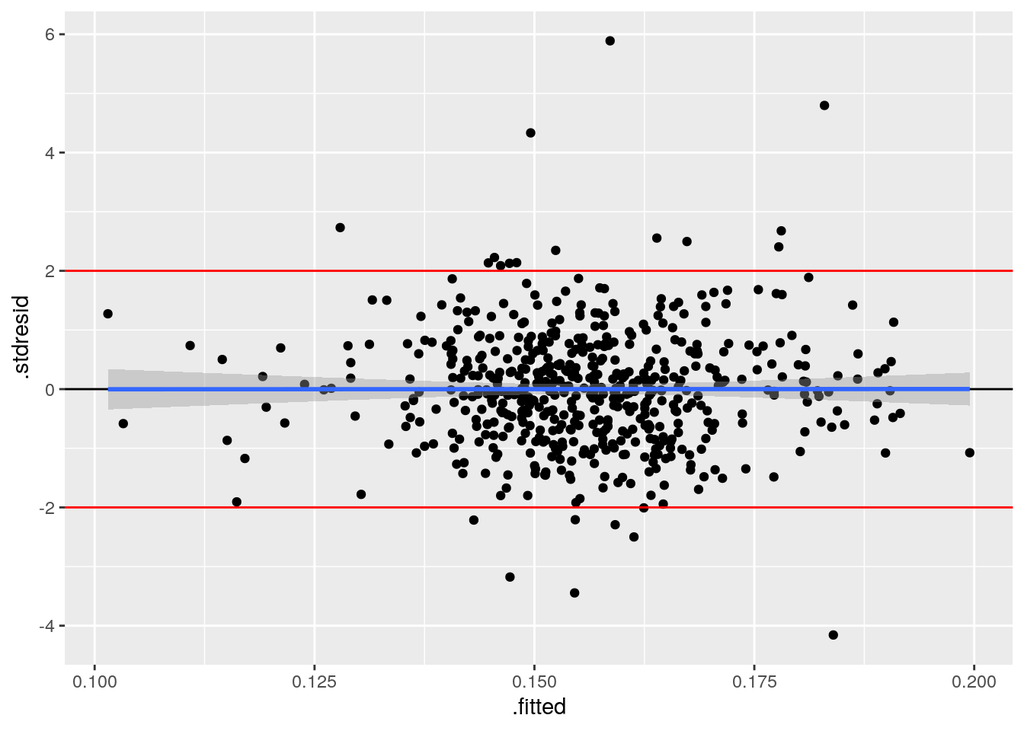

```r
mod_diag <- fortify(optimal_model)
gg_resid <- ggplot(data = mod_diag, aes(x = .fitted, y = .stdresid)) +
  geom_point() +
  geom_hline(yintercept = 0) +
  geom_smooth(method = "lm") +
  geom_hline(yintercept = 2, color = "red") +
  geom_hline(yintercept = -2, color = "red")

gg_resid
```

Сделаем определенные выводы:

- Модель обладает определенной линейностью взаимосвязи
- Относительно много наблюдений находятся за пределеами зоны +- 2 стандартных отклонения
- Гетероскедастичность отсутствует

Неплохо, но довольно сильные отклонения за пределы доверительного интервала смущают.

### 3.1.2 Проверка на выбросы

Для начала, подберём маржу, выход за границу которой будем считать выбросом.

```r
metric <- 4/nrow(prot_expr_omited)
```

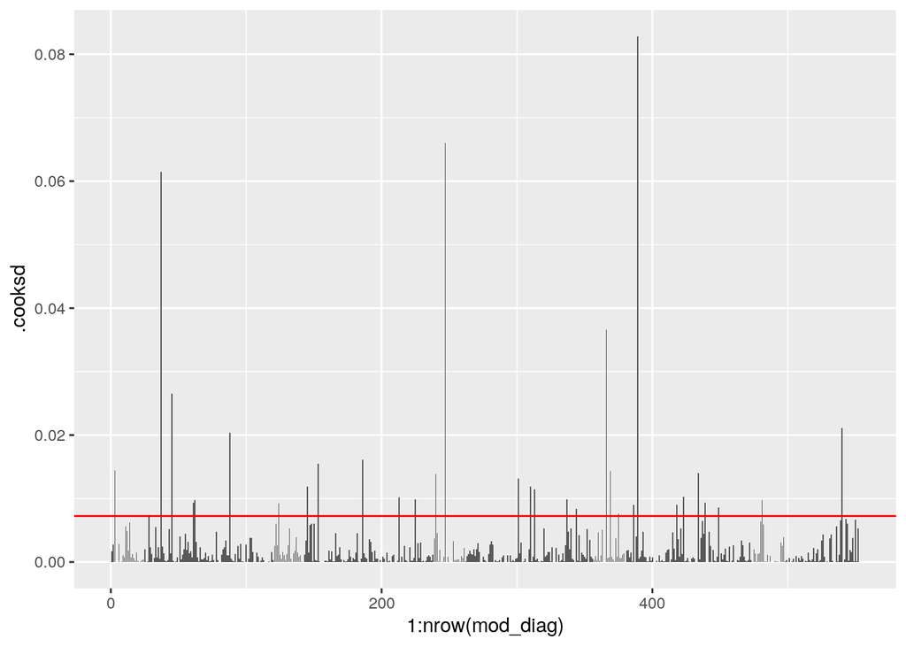

```r
ggplot(mod_diag, aes(x = 1:nrow(mod_diag), y = .cooksd)) +
  geom_bar(stat = "identity") +
  geom_hline(yintercept = metric, color = "red")
```

### 3.1.3 Проверка на наличие независимых наблюдений

```r
durbinWatsonTest(optimal_model)
```

```
##  lag Autocorrelation D-W Statistic p-value
##    1      0.06754625      1.860012   0.008
##  Alternative hypothesis: rho != 0
```

Таким образом, полученная модель не идеальная, но в целом с ней работать можно.

# 4 Сделайте PCA

Проведём ординацию и определим вклад каждой из компонент в изменчивость:

```r
prot_expr_pca <- rda(prot_expr_num, scale = TRUE)
summary(prot_expr_pca)
```

```
##
## Call:
## rda(X = prot_expr_num, scale = TRUE)
##
## Partitioning of correlations:
##               Inertia Proportion
## Total              77          1
## Unconstrained      77          1
##
## Eigenvalues, and their contribution to the correlations
##
## Importance of components:
##                           PC1     PC2     PC3     PC4     PC5     PC6     PC7
## Eigenvalue            23.0488 13.3587 7.58646 7.16154 3.28242 3.04234 2.36733
## Proportion Explained   0.2993  0.1735 0.09853 0.09301 0.04263 0.03951 0.03074
## Cumulative Proportion  0.2993  0.4728 0.57135 0.66436 0.70699 0.74650 0.77724
##                           PC8     PC9    PC10    PC11    PC12    PC13     PC14
## Eigenvalue            2.25528 1.83075 1.27872 1.11166 0.98313 0.86294 0.700922
## Proportion Explained  0.02929 0.02378 0.01661 0.01444 0.01277 0.01121 0.009103
## Cumulative Proportion 0.80653 0.83031 0.84691 0.86135 0.87412 0.88533 0.894428
##                           PC15     PC16     PC17     PC18     PC19     PC20
## Eigenvalue            0.611169 0.569217 0.520420 0.484876 0.418534 0.399046
## Proportion Explained  0.007937 0.007392 0.006759 0.006297 0.005436 0.005182
## Cumulative Proportion 0.902366 0.909758 0.916517 0.922814 0.928249 0.933432
##                           PC21     PC22     PC23     PC24     PC25     PC26
## Eigenvalue            0.387367 0.339991 0.319123 0.292254 0.259013 0.241727
## Proportion Explained  0.005031 0.004415 0.004144 0.003796 0.003364 0.003139
## Cumulative Proportion 0.938462 0.942878 0.947022 0.950818 0.954182 0.957321
##                           PC27    PC28     PC29     PC30     PC31     PC32
## Eigenvalue            0.216222 0.20709 0.182731 0.166772 0.150604 0.136755
## Proportion Explained  0.002808 0.00269 0.002373 0.002166 0.001956 0.001776
## Cumulative Proportion 0.960129 0.96282 0.965192 0.967358 0.969314 0.971090
##                           PC33     PC34     PC35     PC36     PC37    PC38
## Eigenvalue            0.133922 0.124826 0.123532 0.112486 0.105178 0.09622
## Proportion Explained  0.001739 0.001621 0.001604 0.001461 0.001366 0.00125
## Cumulative Proportion 0.972829 0.974450 0.976054 0.977515 0.978881 0.98013
##                           PC39     PC40     PC41     PC42      PC43      PC44
## Eigenvalue            0.091371 0.091173 0.082556 0.079101 0.0734032 0.0725823
## Proportion Explained  0.001187 0.001184 0.001072 0.001027 0.0009533 0.0009426
## Cumulative Proportion 0.981317 0.982501 0.983574 0.984601 0.9855541 0.9864968
```

[output cut: 657 more lines]

[output not shown]

Так как первые две компоненты объясняют более всего изменчивости, построим биплот для них:

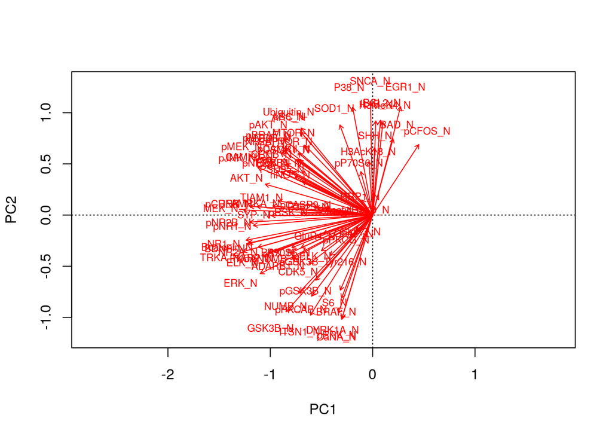

```r
biplot(prot_expr_pca, scaling = "species", display = "species")
```

Посчитаем процент, который объясняет каждая из компонент:

```r
pca_summary <- prcomp(prot_expr_num, scale= T)
eigs <- pca_summary$sdev^2
eigs/sum(eigs)*100
```

```
##  [1] 2.993347e+01 1.734900e+01 9.852545e+00 9.300702e+00 4.262879e+00
##  [6] 3.951090e+00 3.074449e+00 2.928929e+00 2.377603e+00 1.660673e+00
## [11] 1.443715e+00 1.276789e+00 1.120706e+00 9.102884e-01 7.937266e-01
## [16] 7.392430e-01 6.758699e-01 6.297091e-01 5.435506e-01 5.182412e-01
## [21] 5.030734e-01 4.415472e-01 4.144460e-01 3.795503e-01 3.363808e-01
## [26] 3.139310e-01 2.808078e-01 2.689508e-01 2.373127e-01 2.165876e-01
## [31] 1.955898e-01 1.776045e-01 1.739243e-01 1.621116e-01 1.604317e-01
## [36] 1.460860e-01 1.365943e-01 1.249647e-01 1.186631e-01 1.184069e-01
## [41] 1.072162e-01 1.027284e-01 9.532878e-02 9.426271e-02 8.836546e-02
## [46] 8.376818e-02 8.198216e-02 7.506097e-02 7.114074e-02 6.784812e-02
## [51] 6.505619e-02 6.053463e-02 5.922679e-02 5.758969e-02 5.333616e-02
## [56] 5.214279e-02 4.746799e-02 4.286538e-02 4.185007e-02 4.078755e-02
## [61] 3.978400e-02 3.654374e-02 3.492346e-02 3.151554e-02 2.855199e-02
## [66] 2.592935e-02 2.435196e-02 2.360150e-02 2.172045e-02 1.806446e-02
## [71] 1.620218e-02 1.501547e-02 1.443313e-02 1.153629e-02 1.119605e-02
## [76] 7.930867e-03 5.903335e-30
```

Построим 3д график для первых трёх PC:

```r
pca3d(pca_summary)
```

```
## [1] 0.2966606 0.2201412 0.1879875
## Creating new device
```

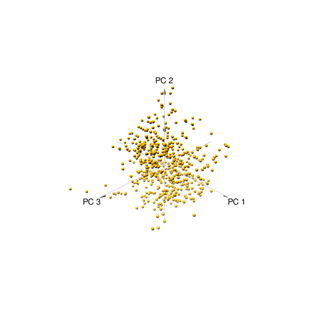

```r
snapshotPCA3d(file="first_plot.png")
```